# Google Trends analysis of teledermatology interest

# Loading libraries

First, we will load the libraries used for the analysis and figures.

```r
library(gtrendsR)
library(data.table)
library(dplyr)
library(ggplot2)
```

# Figure 1

We will get monthly search volume from Google Trends for telehealth and dermatology in the United States from January 01, 2017 to December 31, 2022.

```r
derm.keywords = "telehealth dermatologist + teledoc dermatologist + virtual dermatologist"
start.date = "2017-01-01"
end.date = "2022-12-31"
region = c("US")

derm.res = gtrendsR::gtrends(keyword = derm.keywords,
                             geo = region,
                             gprop = "web",
                             low_search_volume = TRUE,
                             hl = "en-US",
                             time = paste(start.date, end.date))
```

Next, we will smooth the interest over time data over a three month period.

```r
derm.interest.over.time.dt = as.data.table(derm.res$interest_over_time)
derm.interest.over.time.dt[, year := gsub("^(20[0-9]{2})-.*", "\\1", date)]
derm.interest.over.time.dt[, month := as.numeric(gsub("20[0-9]{2}-([0-9]{2})-[0-9]{2}", "\\1", date))]
derm.interest.over.time.dt[, quarter := cut(month, breaks = c(0, 3, 6, 9, 12), labels = c("Jan - Mar", "Apr - Jun", "Jul - Sep", "Oct - Dec"))]
derm.interest.over.time.dt[, label := paste(year, quarter)]
derm.interest.over.time.dt[, month_label := paste(year, quarter)]

derm.interest.over.time.dt[, label_level := ordered(label, levels = pt.dt[order(quarter)][order(year)][, unique(label)])]
derm.interest.over.time.dt[, time_period := ordered(ifelse(year < "2020", "pre-pandemic", ifelse(year == "2020", ifelse(month < 3, "pre-pandemic", "pandemic"), "pandemic")), levels = c("pre-pandemic", "pandemic"))]

pt.dt = derm.interest.over.time.dt[, .(hits = mean(hits)), by = .(label_level, time_period)]
```

Next we make a plot of our results.

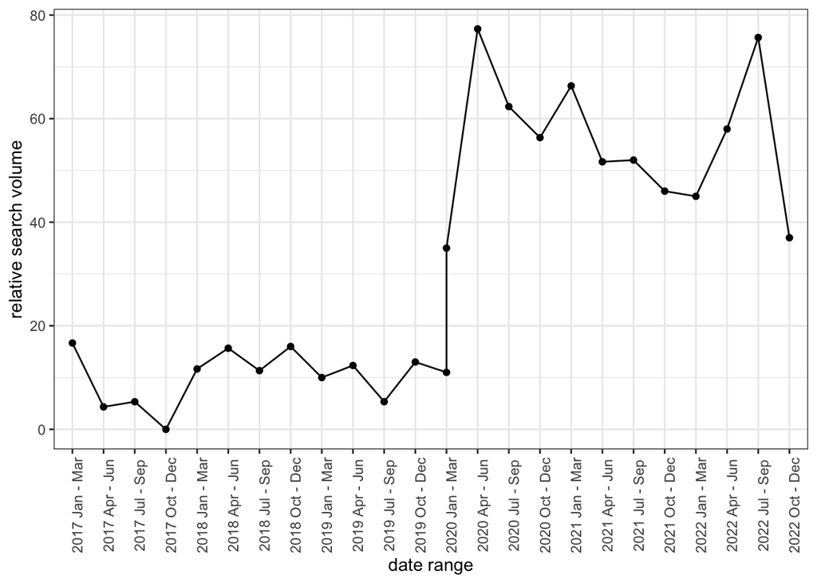

Figure 1a. Teledermatology interest from 2017-2022

```r
pt = ggplot(pt.dt, aes(x = label_level, y = hits)) +
  geom_point() +
  geom_line(aes(x = as.numeric(label_level), y = hits)) +
  labs(x = "date range", y = "relative search volume") +
  theme_bw() +
  theme(axis.text.x = element_text(angle = 90))
```

We will use a boxplot to compare interest in dermatology before and after March 2020.

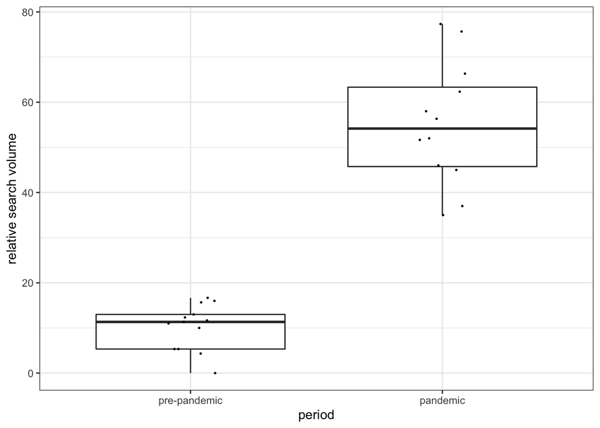

```r
pt = ggplot(pt.dt, aes(x = time_period, y = hits)) +
  geom_boxplot(outlier.shape = NA) +
  geom_jitter(width = 0.1, height = 0, size = 0.3) +
  theme_bw() +
  labs(x = "period",  y = "relative search volume")
```